# Distributions

## Schedule

[output not shown]

# Loss distributions

## The four questions

1. What is the density of a standard normal distribution at x = 0.5?
2. How much probability is contained below x = 0.5?
3. Where does x need to be to get 97.5% of the cumulative probability?
4. What is the mean of 1,000 randomly simulated standard normal variables?

## The four letters

- `d` = density/probability mass
- `p` = cumulative probability
- `q` = quantiles, i.e. inverse of `p`
- `r` = randomly generated values

## The four letters

```r
library(tidyverse)

dnorm(0.5)
```

```
## [1] 0.3520653
```

```r
pnorm(0.5)
```

```
## [1] 0.6914625
```

```r
qnorm(.975)
```

```
## [1] 1.959964
```

```r
rnorm(1e3) %>%
  mean()
```

```
## [1] 0.02353172
```

## Other distributions

| Distribution | Abbreviation | Parameters |
| --- | --- | --- |
| Normal | norm | mean = 0, sd = 1 |
| Logormal | lnorm | meanlog = 0, sdlog = 1 |
| Gamma | gamma | shape, rate = 1 |
| Exponential | exp | rate = 1 |
| Poisson | pois | lambda |
| Negative binomial | nbinom | size, prob |

## Caveat Actuar

Be careful with the parameters. They will not always line up with how they are defined in texts like Loss Models.

Also, some distributions (like the gamma) may have more than one parameterization available.

## Visualization

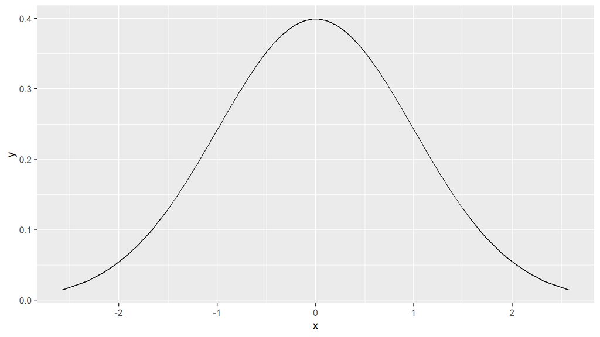

```r
tibble(
    prob = seq(.005, .995, by = .005)
  , x = qnorm(prob)
  , y = dnorm(x)
) %>%
  ggplot(aes(x, y)) +
  geom_line()
```

## Empirical distribution functions

```r
library(raw)

data(COTOR2)
emp_cotor <- ecdf(COTOR2)
```

## Visualize empirical distribution

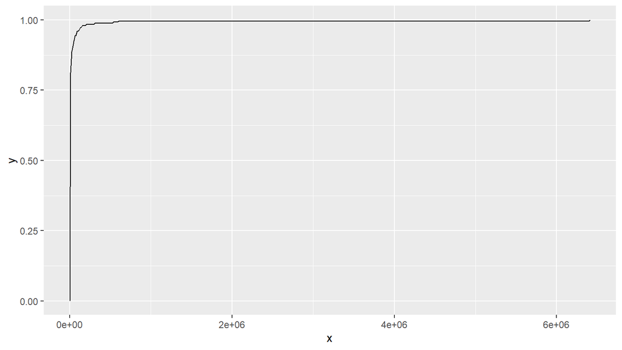

```r
tibble(
    x = seq(0, max(COTOR2), length.out = 500)
  , y = emp_cotor(x)
) %>%
  ggplot(aes(x, y)) +
  geom_line()
```

## Visualize empirical distribution 2

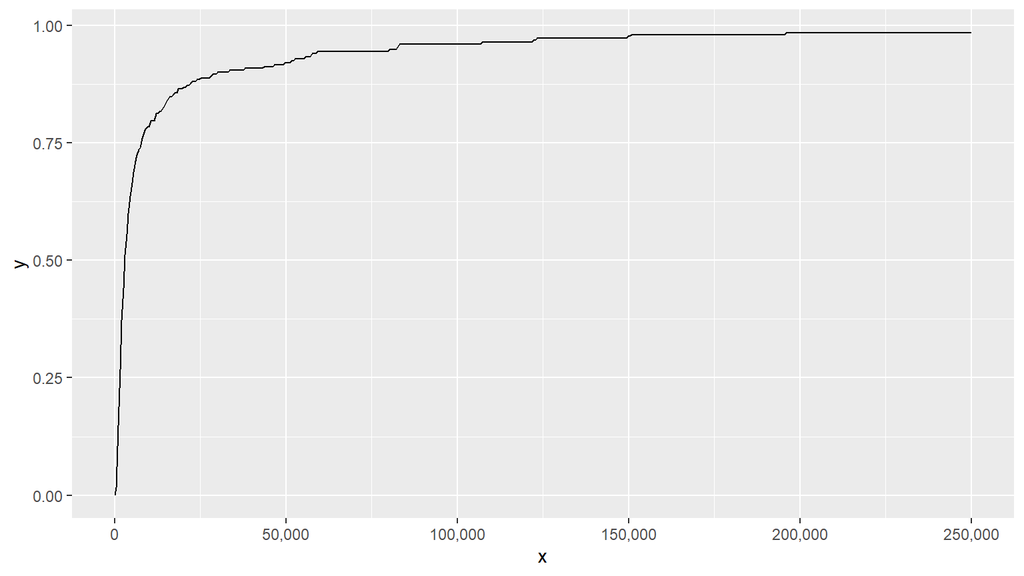

```r
tibble(
    x = seq(0, 250e3, length.out = 500)
  , y = emp_cotor(x)
) %>%
  ggplot(aes(x, y)) +
  geom_line() +
  scale_x_continuous(labels = scales::comma)
```

## `actuar`

Written by Vincent Goulet for his students, and others

Contains additional distributions and some new prefixes

- `m` moment functions
- `lev` limited expected value functions

## New prefixes example

Assume you fit a lognormal to your data and got the parameters shown below.

Using actuar, what was the mean of your data (or close to it)?

```r
library(actuar)

meanlog_est <- 7.9
sdlog_est <- 1.5
mlnorm(1, meanlog = 7.9, sdlog = 1.5)
```

```
## [1] 8308.214
```

## Using `lev`

```r
attachment <- 50e3
limit <- 100e3

lev_upper <- levlnorm(attachment + limit, meanlog = meanlog_est, sdlog = sdlog_est)
lev_lower <- levlnorm(attachment, meanlog = meanlog_est, sdlog = sdlog_est)
ilf <- lev_upper / lev_lower
ilf
```

```
## [1] 1.144781
```

# Simulation

## Basics

Use the `r*()` functions

```r
rpois(5, 10)
```

```
## [1] 12 11  4  3  9
```

```r
rgamma(5, 2, rate = 5)
```

```
## [1] 0.6176457 0.5530007 0.1751232 0.3111475 0.7036324
```

## `sample()`

```r
sims_policy <- 100
regions <- c('north', 'south', 'east', 'west')
sample_regions <- sample(regions, size = sims_policy, replace = TRUE)

sample_regions %>%
  head(4)
```

```
## [1] "south" "west"  "north" "west"
```

## Reproducibly random

```r
rnorm(5)
```

```
## [1] -0.2385337  0.1313703 -0.7238196  1.0077751 -0.5230132
```

```r
rnorm(5)
```

```
## [1] -0.56378286  1.44248756  1.63800574 -0.21554598 -0.03297115
```

```r
set.seed(1234)
rnorm(5)
```

```
## [1] -1.2070657  0.2774292  1.0844412 -2.3456977  0.4291247
```

```r
set.seed(1234)
rnorm(5)
```

```
## [1] -1.2070657  0.2774292  1.0844412 -2.3456977  0.4291247
```

## More complex

```r
num_policies <- 100
num_claims <- rpois(num_policies, 2)
severity <- rgamma(sum(num_claims), rlnorm(sum(num_claims), 10, .2))
policy_id <- rep(seq_len(num_policies), num_claims)
```

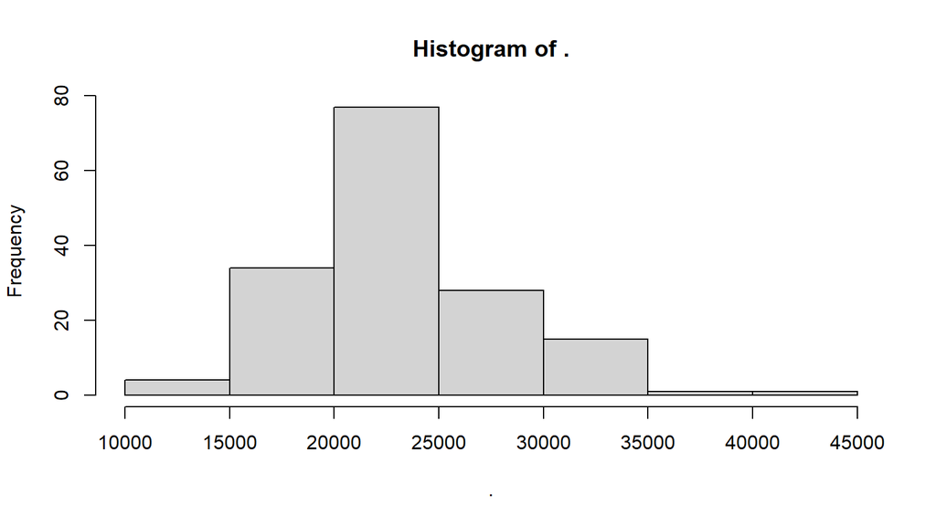

```r
severity %>%
  hist()
```

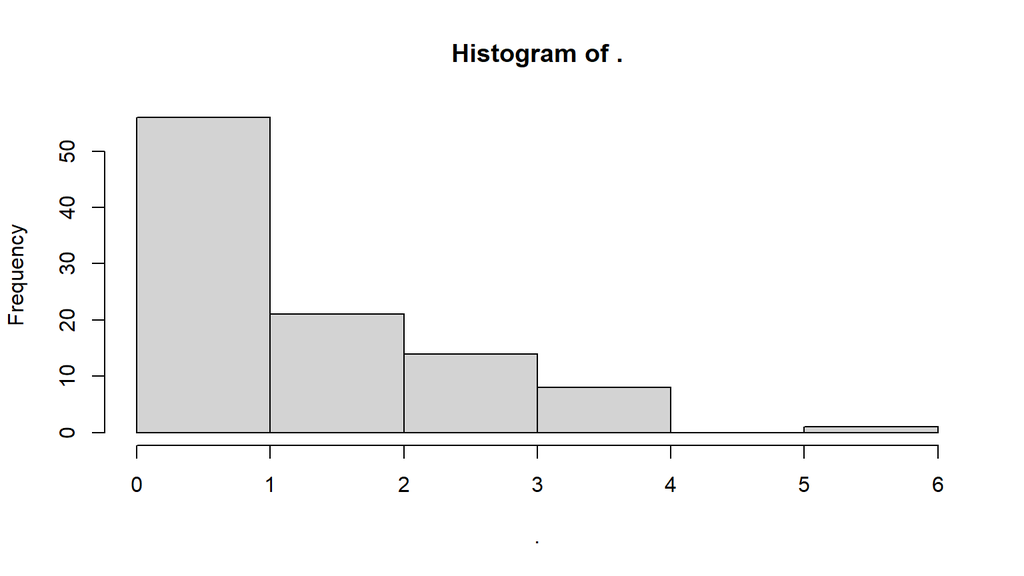

```r
num_claims %>%
  hist()
```

# Fitting a loss distribution

## What we’ll do

- Generate some data
- Visualize it
- Explore the log likelihood
- Fit distributions
- Goodness of fit

## Generate some loss data

```r
set.seed(8910)
sims <- 5e3

scale <- 250
shape <- 8
severity <- rgamma(sims, shape, scale = scale)

summary(severity)
```

```
##    Min. 1st Qu.  Median    Mean 3rd Qu.    Max.
##   250.4  1469.4  1901.2  1994.8  2429.2  5390.6
```

## Visualize it

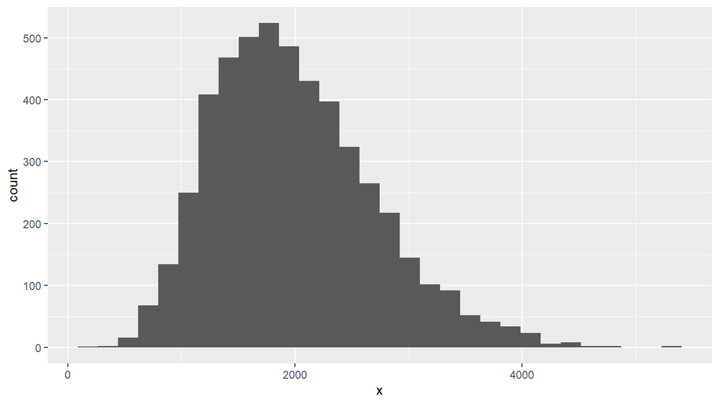

```r
tibble(x = severity) %>%
  ggplot(aes(x)) +
  geom_histogram()
```

## The log-likelihood

```r
dgamma(severity, 0.5, scale = 500, log = TRUE) %>%
  sum()
```

```
## [1] -57182.66
```

```r
dgamma(severity, 0.5, scale = 1e3, log = TRUE) %>%
  sum()
```

```
## [1] -48941.29
```

## Explore the likelihood function

```r
log_like_gamma <- function(sample_in, shape_in, scale_in) {
  dgamma(sample_in, shape_in, scale = scale_in, log = TRUE) %>%
    sum()
}

log_like_gamma(severity, 0.5, 500)
```

```
## [1] -57182.66
```

```r
log_like_gamma(severity, 0.5, 1e3)
```

```
## [1] -48941.29
```

```r
log_like_gamma(severity, 0.5, c(500, 1e3))
```

```
## [1] -53061.72
```

```r
map2_dbl(0.5, c(500, 1e3), log_like_gamma, sample_in = severity)
```

```
## [1] -57182.66 -48941.29
```

## Explore along the shape

```r
tbl_log_like <- tibble(
  shape = seq(0.05, 10, length.out = 500)
  , scale = mean(severity) / shape
  , log_like = map2_dbl(shape, scale, log_like_gamma, sample_in = severity)
)
```

## Visualize

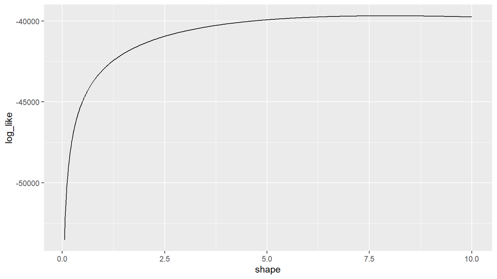

```r
tbl_log_like %>%
  ggplot(aes(shape, log_like)) +
  geom_line()
```

## Explore along the scale

```r
tbl_log_like <- tibble(
  scale = seq(0.01 * min(severity), max(severity) / 2, length.out = 500)
  , shape = mean(severity) / scale
  , log_like = map2_dbl(shape, scale, log_like_gamma, sample_in = severity)
)
```

## Visualize

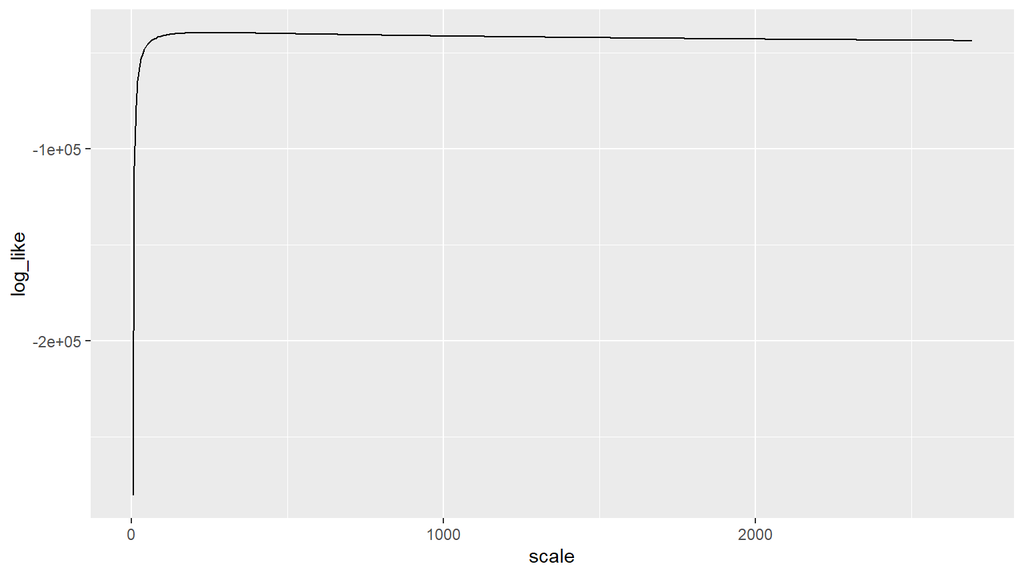

```r
tbl_log_like %>%
  ggplot(aes(scale, log_like)) +
  geom_line()
```

## Explore both

```r
tbl_log_like <- crossing(
    scale = seq(0.5 * min(severity), max(severity), length.out = 100)
  , shape = seq(0.05, 10, length.out = 100)
) %>%
  mutate(
    log_like = map2_dbl(shape, scale, log_like_gamma, sample_in = severity)
    , exp_sev = scale * shape
  )

tbl_sample_mean <- tbl_log_like %>%
  filter(
    abs(exp_sev - mean(severity)) < 100
  )
```

## Visualize

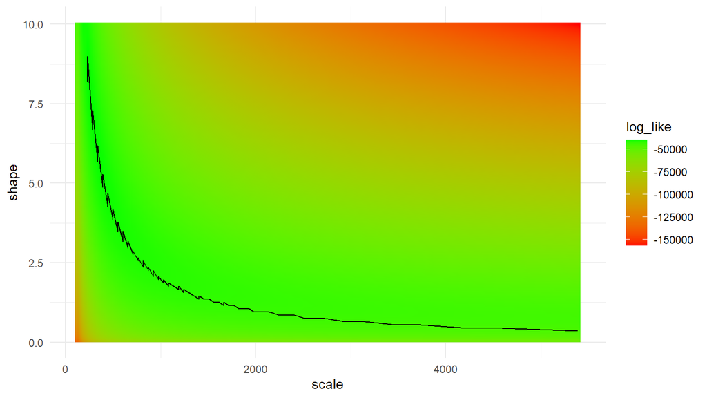

```r
tbl_log_like %>%
  ggplot(aes(scale, shape)) +
  geom_raster(aes(fill = log_like), interpolate = TRUE) +
  scale_fill_continuous(low = 'red', high = 'green') +
  geom_line(data = tbl_sample_mean, color = 'black') +
  theme_minimal()
```

## Visualize

[figure not shown]

# `fitdistr`

## A better way

Directly examining the log-likelihood is instructive, but we don’t do this in practice.

## `fitdistr`

```r
library(MASS)

fitGamma <- fitdistr(severity, "gamma")
fitLognormal <- fitdistr(severity, "lognormal")
fitWeibull <- fitdistr(severity, "Weibull")

fitGamma
```

```
##       shape           rate
##   7.999662e+00   4.011058e-03
##  (1.223052e-01) (6.129035e-05)
```

```r
fitLognormal
```

```
##      meanlog        sdlog
##   7.534331246   0.365362791
##  (0.005167010) (0.003653628)
```

```r
fitWeibull
```

```
##       shape          scale
##   3.002232e+00   2.233063e+03
##  (3.150096e-02) (1.113253e+01)
```

## q-q plot

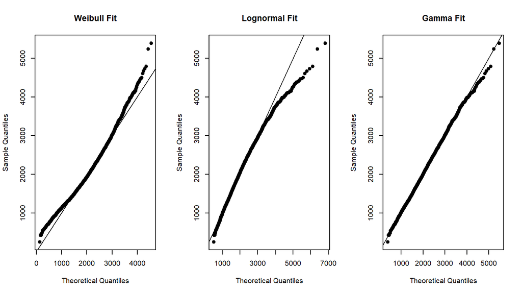

```r
probabilities = seq_len(sims)/(sims + 1)

weibullQ <- qweibull(probabilities, coef(fitWeibull)[1], coef(fitWeibull)[2])
lnQ <- qlnorm(probabilities, coef(fitLognormal)[1], coef(fitLognormal)[2])
gammaQ <- qgamma(probabilities, coef(fitGamma)[1], coef(fitGamma)[2])

sampleLogMean <- fitLognormal$estimate[1]
sampleLogSd <- fitLognormal$estimate[2]

sampleShape <- fitGamma$estimate[1]
sampleRate <- fitGamma$estimate[2]

sampleShapeW <- fitWeibull$estimate[1]
sampleScaleW <- fitWeibull$estimate[2]

sortedSeverity <- sort(severity)
oldPar <- par(mfrow = c(1,3))
plot(sort(weibullQ), sortedSeverity, xlab = 'Theoretical Quantiles', ylab = 'Sample Quantiles', pch=19, main = "Weibull Fit")
abline(0,1)

plot(sort(lnQ), sortedSeverity, xlab = 'Theoretical Quantiles', ylab = 'Sample Quantiles', pch=19, main = "Lognormal Fit")
abline(0,1)

plot(sort(gammaQ), sortedSeverity, xlab = 'Theoretical Quantiles', ylab = 'Sample Quantiles', pch=19, main = "Gamma Fit")
abline(0,1)

par(oldPar)
```

## Compare fit to histogram

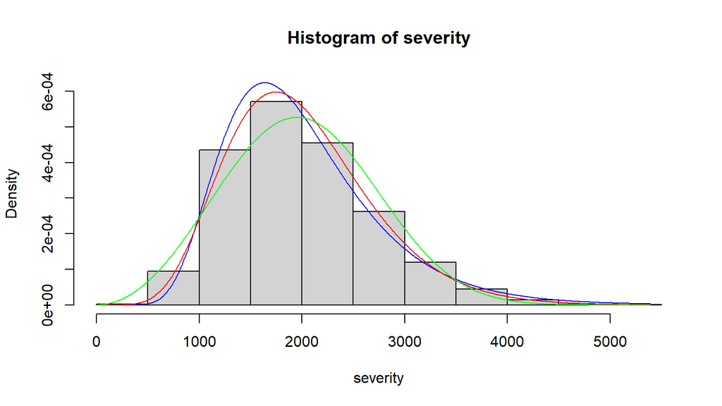

```r
x <- seq(0, max(severity), length.out=500)
yLN <- dlnorm(x, sampleLogMean, sampleLogSd)
yGamma <- dgamma(x, sampleShape, sampleRate)
yWeibull <- dweibull(x, sampleShapeW, sampleScaleW)

hist(severity, freq=FALSE, ylim=range(yLN, yGamma))

lines(x, yLN, col="blue")
lines(x, yGamma, col="red")
lines(x, yWeibull, col="green")
```

## Kolmogorov-Smirnov

The Kolmogorov-Smirnov test measures the distance between an sample distribution and a candidate loss distribution. More formal than q-q plots.

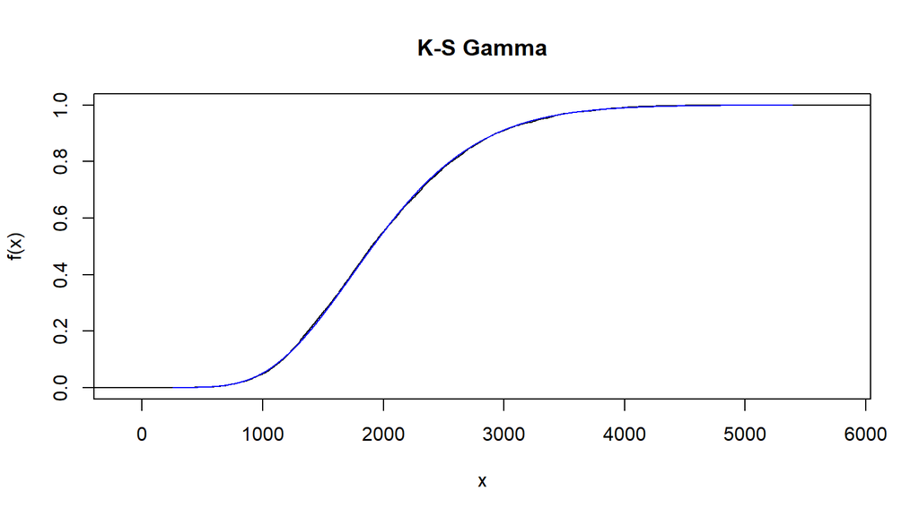

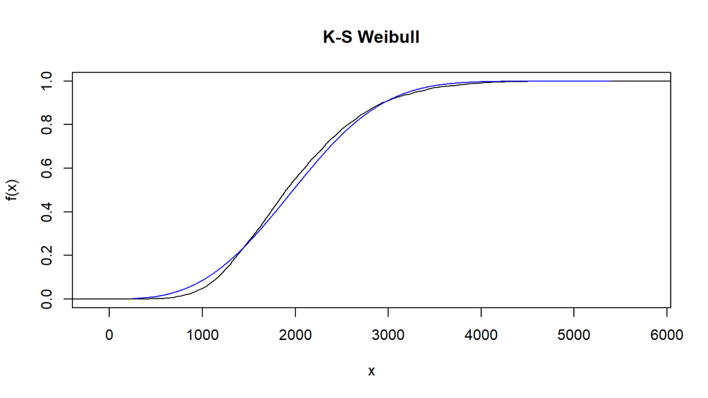

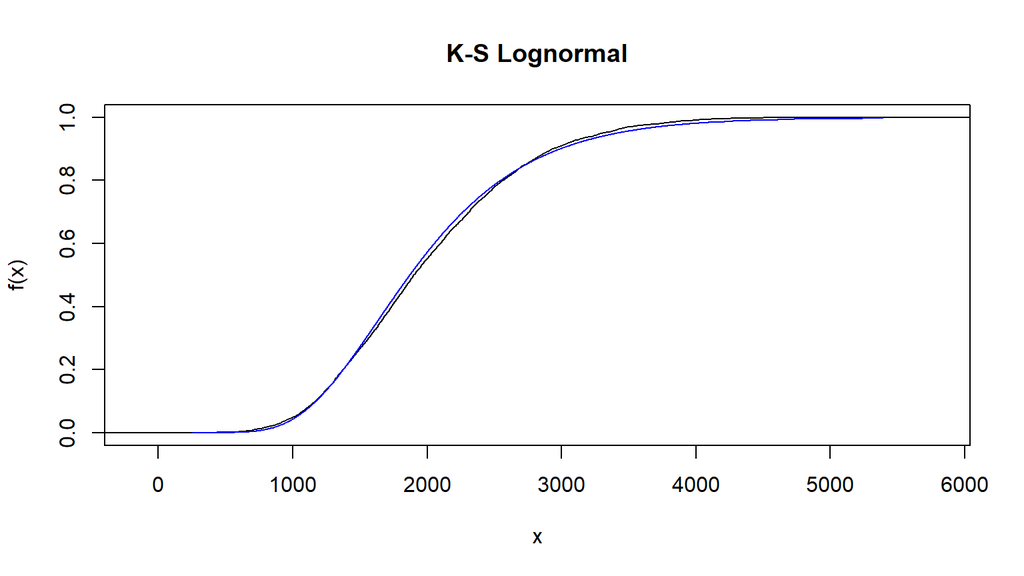

```r
sampleCumul <- seq(1, length(severity)) / length(severity)
stepSample  <- stepfun(sortedSeverity, c(0, sampleCumul), f = 0)
yGamma <- pgamma(sortedSeverity, sampleShape, sampleRate)
yWeibull <- pweibull(sortedSeverity, sampleShapeW, sampleScaleW)
yLN <- plnorm(sortedSeverity, sampleLogMean, sampleLogSd)

plot(stepSample, col = "black", main = "K-S Gamma")
lines(sortedSeverity, yGamma, col = "blue")

plot(stepSample, col = "black", main = "K-S Weibull")
lines(sortedSeverity, yWeibull, col = "blue")

plot(stepSample, col = "black", main = "K-S Lognormal")
lines(sortedSeverity, yLN, col = "blue")
```

## More K-S

A low value for D indicates that the selected curve is fairly close to our data. The p-value indicates the chance that D was produced by the null hypothesis.

```r
testGamma <- ks.test(severity, "pgamma", sampleShape, sampleRate)
testLN <- ks.test(severity, "plnorm", sampleLogMean, sampleLogSd)
testWeibull <- ks.test(severity, "pweibull", sampleShapeW, sampleScaleW)

testGamma
```

```
##
##  One-sample Kolmogorov-Smirnov test
##
## data:  severity
## D = 0.0095988, p-value = 0.7463
## alternative hypothesis: two-sided
```

```r
testLN
```

```
##
##  One-sample Kolmogorov-Smirnov test
##
## data:  severity
## D = 0.024647, p-value = 0.0046
## alternative hypothesis: two-sided
```

```r
testWeibull
```

```
##
##  One-sample Kolmogorov-Smirnov test
##
## data:  severity
## D = 0.041326, p-value = 7.658e-08
## alternative hypothesis: two-sided
```

# Direct optimization

The `optim` function will optimize a function. Works very similar to the Solver algorithm in Excel. `optim` takes a function as an argument, so let’s create a function.

```r
quadraticFun <- function(a, b, c){
  function(x) a*x^2 + b*x + c
}

myQuad <- quadraticFun(a=4, b=-3, c=3)
```

## Direct optimization

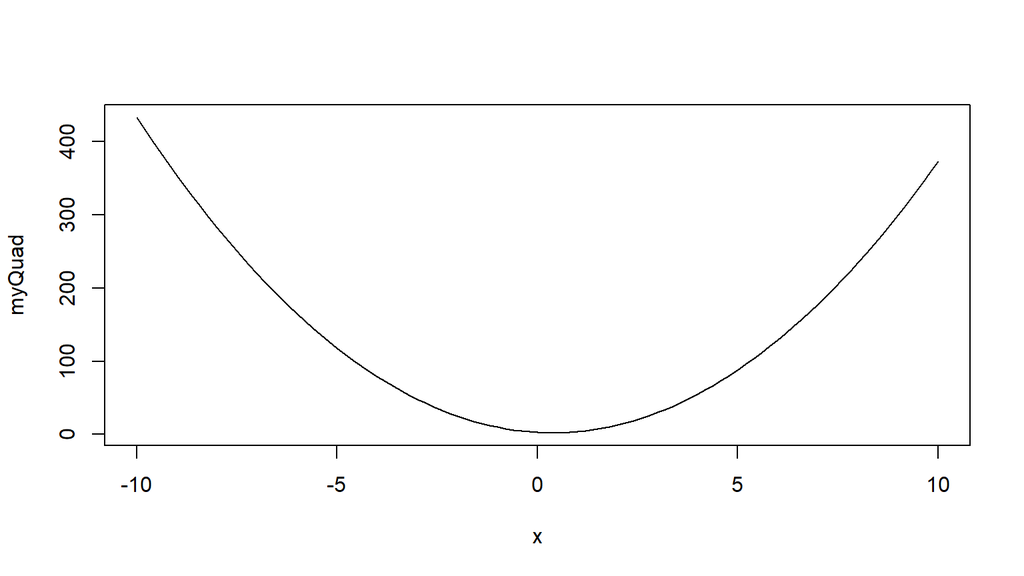

## Direct optimization

8 is our initial guess. A good initial guess will speed up conversion.

```r
myResult <- optim(8, myQuad)
myResult
```

```
## $par
## [1] 0.4
##
## $value
## [1] 2.44
##
## $counts
## function gradient
##       20       NA
##
## $convergence
## [1] 0
##
## $message
## NULL
```

## Direct optimization

Default is to minimize. Set the parameter `fnscale` to something negative to convert to a maximization problem.

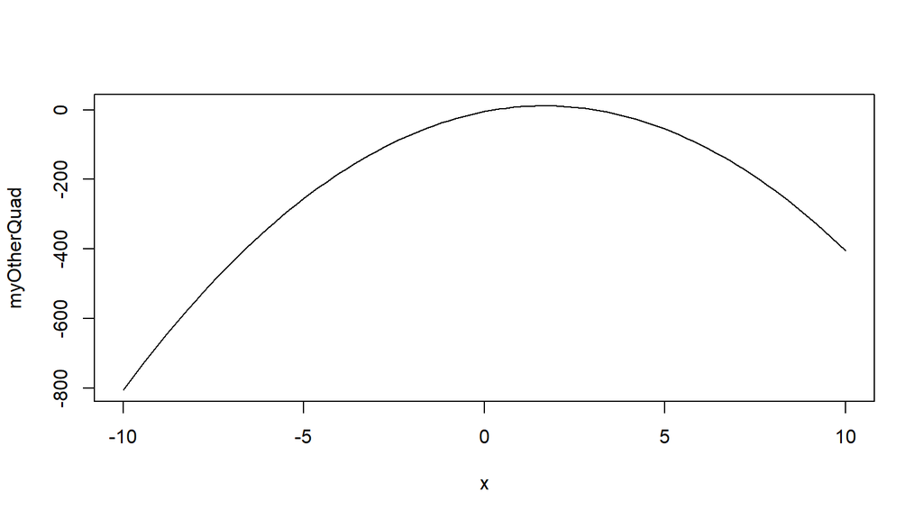

```r
myOtherQuad <- quadraticFun(-6, 20, -5)
plot(myOtherQuad, -10, 10)
```

## Direct optimization

```r
myResult <- optim(8, myOtherQuad)
myResult
```

```
## $par
## [1] 1.447401e+75
##
## $value
## [1] -1.256982e+151
##
## $counts
## function gradient
##      502       NA
##
## $convergence
## [1] 1
##
## $message
## NULL
```

```r
myResult <- optim(8, myOtherQuad, control = list(fnscale=-1))
myResult
```

```
## $par
## [1] 1.666406
##
## $value
## [1] 11.66667
##
## $counts
## function gradient
##       30       NA
##
## $convergence
## [1] 0
##
## $message
## NULL
```

## Direct optimization

Direct optimization allows us to create another objective function to maximize, or work with loss distributions for which there isn’t yet support in a package like `actuar`. May be used for general purpose optimization problems, e.g. maximize rate of return for various capital allocation methods.

Note that optimization is a general, solved problem. Things like the simplex method already have package solutions in R. You don’t need to reinvent the wheel!

# Questions

## Your turn

- Simulate one thousand observations from a weibull distribution
- Fit this against gamma and exponential distributions
- Try that again with only 100 observations (tip: you don’t need to generate the samples again. You can simply subset the vector you created in the first step.)